# Computer Practical 2: Plotting with ggplot2 (continued) and testing for normality

## 13.3 Exercise 11

Test whether the time it takes for a pirate to draw their sword (‘sword.time’) is normally distributed by plotting a histogram and conducting a Shapiro-Wilk test. Is it normally distributed?

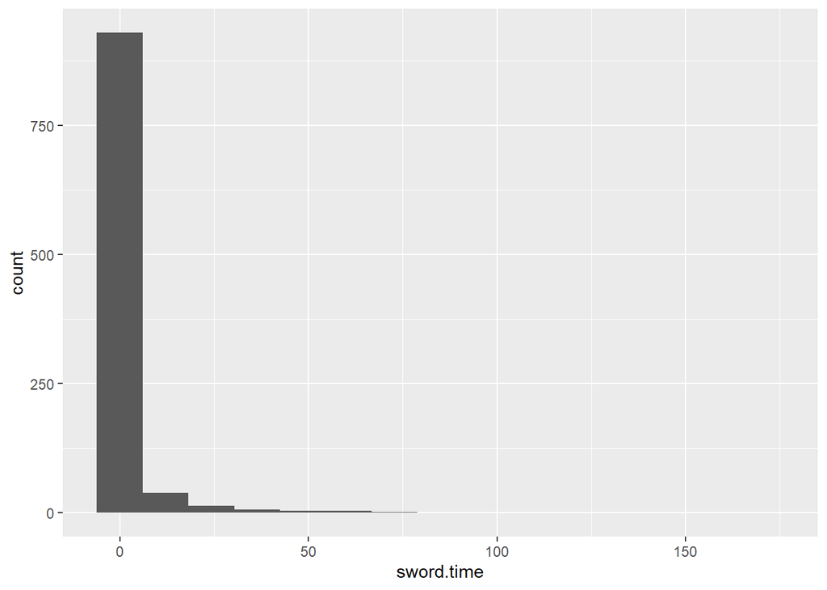

```r
ggplot(pirates, aes(x = sword.time))+geom_histogram(bins = 15)
```

```r
shapiro.test(pirates$sword.time)
```

```
##
##  Shapiro-Wilk normality test
##
## data:  pirates$sword.time
## W = 0.23921, p-value < 2.2e-16
```

```r
# ANSWER: No, sword time is NOT normally distributed. Histogram shows it is very right skewed, and shapiro test indicates that p < 0.05.
```

# 14 Homework

As with last weeks homework, lets use the penguin dataset from the package palmerpenguins to practice some of the things you learned in this practical on a real biological dataset.

```r
#install.packages("palmerpenguins") # install palmerpenguins package if you haven't already

library(palmerpenguins) # load palmerpenguins package

# note- if you get an error it means you haven't installed it. Go back to the homework section of Prac 1 to do this.

data(penguins) # load the penguin dataset

?penguins # check out information for the dataset

View(penguins) # check out the dataset, making a note of the column names
```

## 14.1 Exercise 12

Plot the relationship between flipper length and bill length in penguins, and colour the points by species. Add a trendline, with the trendlines also coloured by species. Make sure the x and y axes are labelled neatly, with units. Colour the different species with the colours “brown3”, “blue4”, and “darkcyan”.

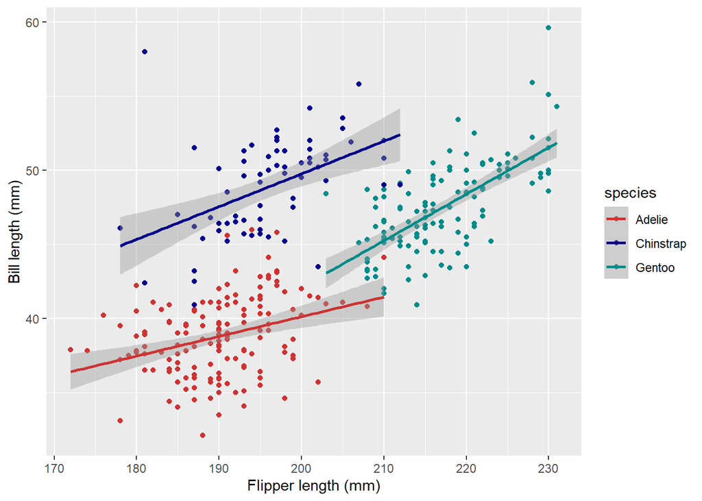

```r
ggplot(penguins, aes(x = flipper_length_mm, y = bill_length_mm, col = species))+
  geom_point()+
  geom_smooth(method = "lm")+
  scale_color_manual(values = c("brown3", "blue4", "darkcyan"))+
  xlab("Flipper length (mm)")+
  ylab("Bill length (mm)")
```

## 14.2 Exercise 13

Assess if penguin bill length is normally distributed by plotting a histogram and doing a Shapiro-Wilk test.

Remember, in scientific notation, 5e-5 means you move the decimal point five places to the left. So, 5e-5 = 0.00005. Why do you think bill length has an odd distribution? To find out, colour the histogram by species (using *fill = species*).

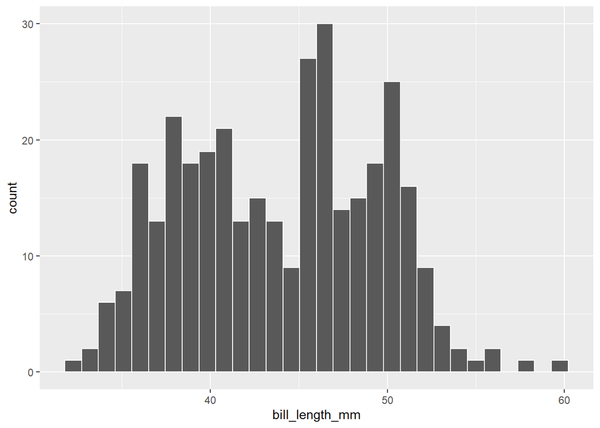

```r
ggplot(penguins, aes(x = bill_length_mm))+geom_histogram(col = "white")
```

```r
shapiro.test(penguins$bill_length_mm)
```

```
##
##  Shapiro-Wilk normality test
##
## data:  penguins$bill_length_mm
## W = 0.97485, p-value = 1.12e-05
```

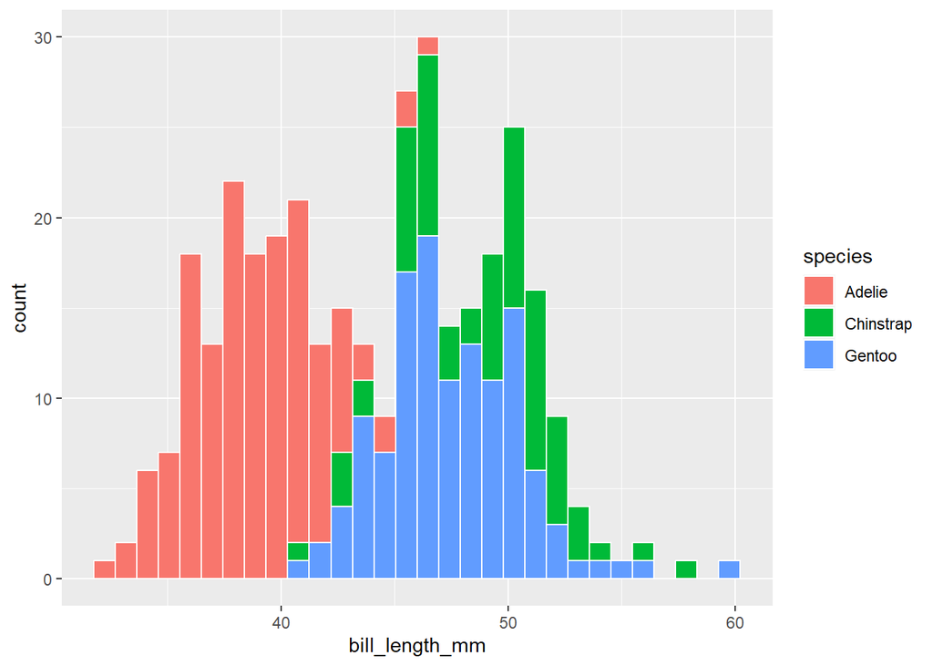

```r
# According to the histogram and the results of a Shapiro-Wilk test, bill length is NOT normally distributed.

ggplot(penguins, aes(x = bill_length_mm, fill = species))+geom_histogram(col = "white")
```

```r
# This is because bill lengths differ by species, causing an odd distribution
```